# Credit card fraud detection with Machine Learning in R

In this R project, I will discuss the Credit Card Fraud Detection Project using Machine Learning and R concepts. I will perform detection of credit cards. I will go through the CART (Classification and Regression Tree) algorithms. For carrying out the credit card fraud detection, I will make use of the Card Transactions dataset that contains a mix of fraud as well as non-fraudulent transactions.

### Objective

```r
library(ggplot2)
library(data.table)
library(tidyverse)
library(caret)
library(smotefamily)
library(rpart)
library(rpart.plot)
```

We are importing the datasets that contain transactions made by credit cards.

The Credit Card Fraud detection Dataset contains transactions made by credit cards in September 2013 by European cardholders.

### Loading the dataset and convert Class to a factor variable

```r
url = "E:/A_Projects/creditcard.csv"
data <- read.csv(url)
```

```r
data$Class <- factor(data$Class, levels = c(0,1))
```

This dataset present transactions that occurred in two days, where we have 284807 transactions.

### Exploratory data analysis

In this section of the fraud detection ML project, we will explore the creditcard data that is contained in the data dataframe. We will proceed by displaying data using the head() function. We will then proceed to explore the other components of this dataframe.

```r
dim(data)
```

```
[1] 284807     31
```

```r
head(data, 6)
```

|  | Time | V1 | V2 | V3 | V4 | V5 | V6 | V7 | V8 | V9 | V10 | V11 | V12 | V13 | V14 | V15 | V16 | V17 | V18 | V19 | V20 | V21 | V22 | V23 | V24 | V25 | V26 | V27 | V28 | … |
| --- | --- | --- | --- | --- | --- | --- | --- | --- | --- | --- | --- | --- | --- | --- | --- | --- | --- | --- | --- | --- | --- | --- | --- | --- | --- | --- | --- | --- | --- | --- |
| 1 | 0 | -1.3598071 | -0.07278117 | 2.5363467 | 1.3781552 | -0.33832077 | 0.46238778 | 0.23959855 | 0.09869790 | 0.3637870 | 0.09079417 | -0.5515995 | -0.61780086 | -0.9913898 | -0.3111694 | 1.4681770 | -0.4704005 | 0.20797124 | 0.02579058 | 0.40399296 | 0.25141210 | -0.018306778 | 0.277837576 | -0.11047391 | 0.06692807 | 0.1285394 | -0.1891148 | 0.133558377 | -0.02105305 | … |
| 2 | 0 | 1.1918571 | 0.26615071 | 0.1664801 | 0.4481541 | 0.06001765 | -0.08236081 | -0.07880298 | 0.08510165 | -0.2554251 | -0.16697441 | 1.6127267 | 1.06523531 | 0.4890950 | -0.1437723 | 0.6355581 | 0.4639170 | -0.11480466 | -0.18336127 | -0.14578304 | -0.06908314 | -0.225775248 | -0.638671953 | 0.10128802 | -0.33984648 | 0.1671704 | 0.1258945 | -0.008983099 | 0.01472417 | … |
| 3 | 1 | -1.3583541 | -1.34016307 | 1.7732093 | 0.3797796 | -0.50319813 | 1.80049938 | 0.79146096 | 0.24767579 | -1.5146543 | 0.20764287 | 0.6245015 | 0.06608369 | 0.7172927 | -0.1659459 | 2.3458649 | -2.8900832 | 1.10996938 | -0.12135931 | -2.26185710 | 0.52497973 | 0.247998153 | 0.771679402 | 0.90941226 | -0.68928096 | -0.3276418 | -0.1390966 | -0.055352794 | -0.05975184 | … |
| 4 | 1 | -0.9662717 | -0.18522601 | 1.7929933 | -0.8632913 | -0.01030888 | 1.24720317 | 0.23760894 | 0.37743587 | -1.3870241 | -0.05495192 | -0.2264873 | 0.17822823 | 0.5077569 | -0.2879237 | -0.6314181 | -1.0596472 | -0.68409279 | 1.96577500 | -1.23262197 | -0.20803778 | -0.108300452 | 0.005273597 | -0.19032052 | -1.17557533 | 0.6473760 | -0.2219288 | 0.062722849 | 0.06145763 | … |
| 5 | 2 | -1.1582331 | 0.87773675 | 1.5487178 | 0.4030339 | -0.40719338 | 0.09592146 | 0.59294075 | -0.27053268 | 0.8177393 | 0.75307443 | -0.8228429 | 0.53819555 | 1.3458516 | -1.1196698 | 0.1751211 | -0.4514492 | -0.23703324 | -0.03819479 | 0.80348692 | 0.40854236 | -0.009430697 | 0.798278495 | -0.13745808 | 0.14126698 | -0.2060096 | 0.5022922 | 0.219422230 | 0.21515315 | … |
| 6 | 2 | -0.4259659 | 0.96052304 | 1.1411093 | -0.1682521 | 0.42098688 | -0.02972755 | 0.47620095 | 0.26031433 | -0.5686714 | -0.37140720 | 1.3412620 | 0.35989384 | -0.3580907 | -0.1371337 | 0.5176168 | 0.4017259 | -0.05813282 | 0.06865315 | -0.03319379 | 0.08496767 | -0.208253515 | -0.559824796 | -0.02639767 | -0.37142658 | -0.2327938 | 0.1059148 | 0.253844225 | 0.08108026 | … |

All the features, apart from “time” and “amount” are anonymised.

Let’s see whether there is any missing data.

```r
apply(data, 2, function(x) sum(is.na(x)))
```

```
  Time     V1     V2     V3     V4     V5     V6     V7     V8     V9    V10    V11    V12    V13
     0      0      0      0      0      0      0      0      0      0      0      0      0      0
   V14    V15    V16    V17    V18    V19    V20    V21    V22    V23    V24    V25    V26    V27
     0      0      0      0      0      0      0      0      0      0      0      0      0      0
   V28 Amount  Class
     0      0      0
```

There are no NA values in the data.

The class variable take the value 1 in case of fraud and 0 othervwise.

```r
table(data$Class)
```

```
     0      1
284315    492
```

```r
labels <- c("Not Fraud", "fraud")
labels <- paste(labels, round(100*prop.table(table(data$Class)), 2))
labels <- paste(labels, "%")
labels
```

```
[1] "Not Fraud 99.83 %" "fraud 0.17 %"
```

We have 492 frauds out of 284,807 transactions. The dataset is highly unbalanced, the positive class (frauds) account for 0.17% of all transactions.

```r
data %>% group_by(data$Class)  %>%  summarise(mean(Amount), median(Amount))
```

| data$Class | mean(Amount) | median(Amount) |
| --- | --- | --- |
| 0 | 88.29102 | 22.00 |
| 1 | 122.21132 | 9.25 |

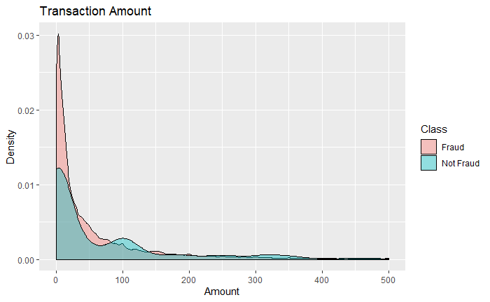

```r
ggplot(data, aes(x = Amount, fill = Class)) +
  geom_density(alpha = 0.4) +
  scale_x_continuous(limits = c(0, 500), breaks = seq(0, 500, 100)) +
  labs(title = "Transaction Amount",
       x = "Amount",
       y = "Density",
       col = "Class") +
  scale_fill_discrete(labels = c("Fraud", "Not Fraud"))
```

### Model development

```r
set.seed(42)
train_index <- createDataPartition(y = data$Class, times = 1, p = 0.8, list = F)
train_data <- data[train_index,]
test_data <- data[-train_index,]
```

SMOTE

```r
n0 <- 227452
n1 <- 394
r0 <- 0.6
#Calculate dup_size
ntimes <- ((1-r0) / r0) * (n0 / n1) - 1

smote_output <- SMOTE(X = train_data[ , -c(1, 31)],
                      target = train_data$Class,
                      K = 5,
                      dup_size = ntimes)

credit_smote <- smote_output$data
colnames(credit_smote)[30] <- "Class"
```

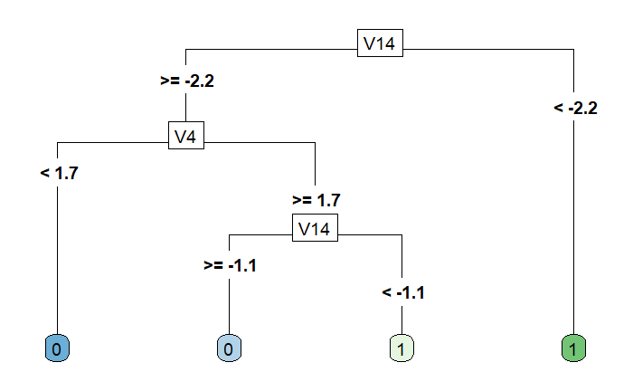

```r
CART_model <- rpart(Class ~ ., credit_smote)
rpart.plot(CART_model, extra = 0, type = 5, tweak = 1.2)
```

#### Predicting fraud classes wiht CART model

```r
predicted_val <- predict(CART_model, test_data, type = 'class')
```

```r
# Build confusion matrix
confusionMatrix(predicted_val, test_data$Class)
```

```
Confusion Matrix and Statistics

          Reference
Prediction     0     1
         0 55601    12
         1  1262    86

               Accuracy : 0.9776
                 95% CI : (0.9764, 0.9788)
    No Information Rate : 0.9983
    P-Value [Acc > NIR] : 1

                  Kappa : 0.1161

 Mcnemar's Test P-Value : <2e-16

            Sensitivity : 0.9778
            Specificity : 0.8776
         Pos Pred Value : 0.9998
         Neg Pred Value : 0.0638
             Prevalence : 0.9983
         Detection Rate : 0.9761
   Detection Prevalence : 0.9763
      Balanced Accuracy : 0.9277

       'Positive' Class : 0
```